# Assignment 1

Manuel

8 Februar 2017

============

## Loading and preprocessing the data

Load packages and read data.

```r
library(tidyverse)
activity <- read_csv("H:/Kurse/DataScience/ReproducibleResearch/Assignment1/activity.csv", col_types = cols(steps = col_number()))
```

## What is mean total number of steps taken per day?

Group by date and calculate sum of steps per day

```r
sum_steps <- activity %>% group_by(date) %>% summarise (sum = sum (steps))
```

Make a histogram of the sum of steps per day

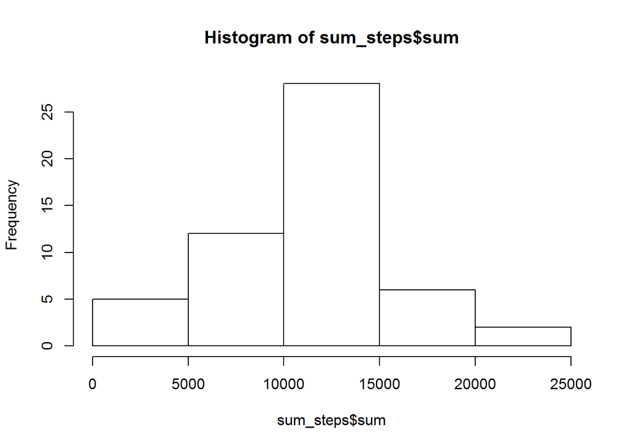

```r
hist(sum_steps$sum)
```

Calculate the mean and median steps per day

```r
sum_steps %>% group_by(date) %>% summarise (mean = mean(sum), median = median (sum, na.rm = TRUE))
```

```
## # A tibble: 61 × 3
##          date  mean median
##        <date> <dbl>  <dbl>
## 1  2012-10-01    NA     NA
## 2  2012-10-02   126    126
## 3  2012-10-03 11352  11352
## 4  2012-10-04 12116  12116
## 5  2012-10-05 13294  13294
## 6  2012-10-06 15420  15420
## 7  2012-10-07 11015  11015
## 8  2012-10-08    NA     NA
## 9  2012-10-09 12811  12811
## 10 2012-10-10  9900   9900
## # ... with 51 more rows
```

## What is the average daily activity pattern?

Make a time series plot (i.e. type = “l”) of the 5-minute interval (x-axis) and the average number of steps taken, averaged across all days (y-axis)

# Calculate the mean of steps per interval across all days

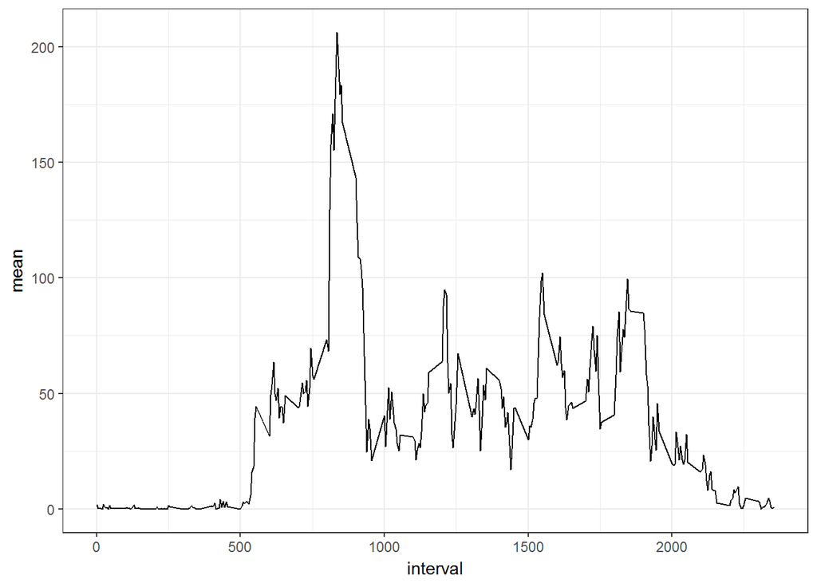

```r
intervals <- activity %>% group_by(interval) %>% summarise (mean=mean(steps, na.rm = TRUE))

ggplot(intervals, aes(x =  interval, y = mean)) +
  geom_line() +
  theme_bw()
```

Which 5-minute interval, on average across all the days in the dataset, contains the maximum number of steps?

```r
intervals %>% arrange(desc(mean))
```

```
## # A tibble: 288 × 2
##    interval     mean
##       <int>    <dbl>
## 1       835 206.1698
## 2       840 195.9245
## 3       850 183.3962
## 4       845 179.5660
## 5       830 177.3019
## 6       820 171.1509
## 7       855 167.0189
## 8       815 157.5283
## 9       825 155.3962
## 10      900 143.4528
## # ... with 278 more rows
```

## Imputing missing values

Calculate NAs

```r
sum(is.na(activity$steps))
```

```
## [1] 2304
```

Devise a strategy for filling in all of the missing values in the dataset. The strategy does not need to be sophisticated. For example, you could use the mean for that 5-minute interval. Create a new dataset that is equal to the original dataset but with the missing data filled in.

```r
activity_imputed <- activity %>% group_by(interval) %>% mutate(steps = replace(steps, is.na(steps), mean(steps, na.rm=TRUE)))
sum(is.na(activity_imputed$steps))
```

```
## [1] 0
```

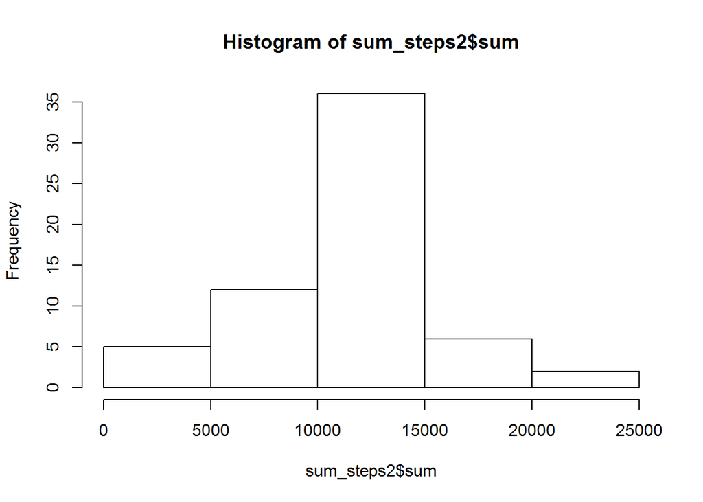

```r
sum_steps2 <- activity_imputed %>% group_by(date) %>% summarise (sum = sum (steps))
hist(sum_steps2$sum)
```

## Are there differences in activity patterns between weekdays and weekends?

Create a new factor variable in the dataset with two levels – “weekday” and “weekend” indicating whether a given date is a weekday or weekend day.

```r
activity_imputed <- activity_imputed %>% mutate(date, Weekday = weekdays(date))
activity_imputed <- activity_imputed %>% mutate(Weekday = ifelse(Weekday == "Sonntag" | Weekday == "Samstag", "Weekend", "Workday"))
```

Make a panel plot containing a time series plot (i.e. type = “l”) of the 5-minute interval (x-axis) and the average number of steps taken, averaged across all weekday days or weekend days (y-axis).

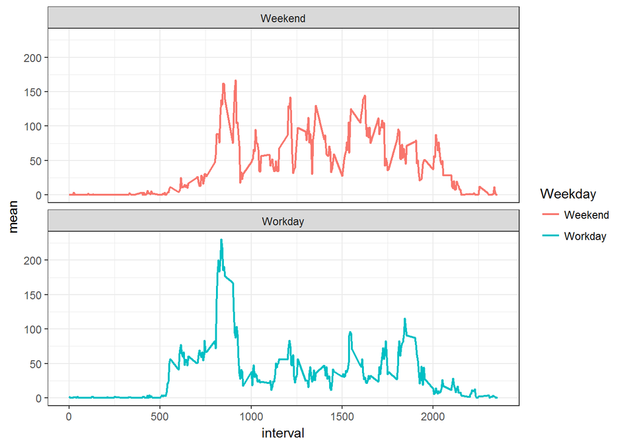

```r
interval2 <- activity_imputed %>% group_by(Weekday, interval) %>% summarise (mean = mean (steps))

ggplot(interval2, aes ( x = interval, y = mean, color = Weekday)) +
         geom_line(size = 0.8) +
         facet_wrap(~Weekday, ncol = 1, nrow=2) +
         theme_bw()
```